# Audio Alchemy

INFO 523 - Final Project

Project description

Author

Affiliation

Nathan Herling & Yashi Mi

College of Information Science, University of Arizona

## A note on spectographic features of `.mp3` vs. `.wav`

Initially, it was assumed that the typical size difference between .mp3 and .wav files would reflect meaningful differences in their spectral properties. However, analysis revealed that the differences were minimal, leading us to abandon the idea of using the two file types as comparative baselines for our models. As shown in Figure 1, the typical similarity between `.wav` and `.mp3` files exceeds 98%, rendering the expectation of differing training results between the two data types a moot point.

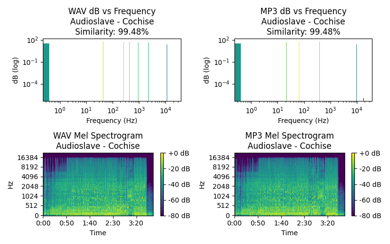

Figure 1: Frequency histogram comparison between MP3 and WAV audio files.

## A note on project software

It’s generally easier and faster to run Python scrips separately and use the results in the discussion of the results. All scripts used are stored in:  
`Herling-Mi_extra\0_mL_scripts\0_p1`  
`Herling-Mi_extra\0_mL_scripts\0_p2`

## Questions

### 1. Language Recognition with Separated Vocal & Audio Tracks

#### **Initial Problem Formulation**

How can we leverage **statistical** and **time-frequency features** extracted from separated vocal and audio tracks to build effective language recognition models? Specifically, how can traditional machine learning methods — ranging from **classical classifiers** on simple statistical summaries to **Gaussian Mixture Models** on richer time-frequency features — be applied in this context?

- What are the key **benefits** and **limitations** of these approaches?
- How can **careful feature engineering**, **feature integration**, and **thorough model evaluation** improve the accuracy and robustness of language recognition systems?
- How do model results compare and contrast when using `.wav` files versus `.mp3` files?

#### **Secondary Problem formulation**

From the initial formulation, we refined the question to specifically compare how different ablations of the audio track (complete song, vocal-only, and non-vocal) affect model performance.

- How does model performance differ when predicting song language using features from complete songs, vocal-only tracks, and instrumental-only tracks?
- What are the relative strengths and limitations of classical machine learning models (Logistic Regression, Random Forest, SVM) when applied to language recognition?

### 2. Recommendation Systems Using Audio Features & User Data

#### **Initial Problem Formulation**

How can **user interaction data**, combined with basic track metadata and simple audio features, be used to build an effective recommendation system using **collaborative filtering** and traditional machine learning methods?

- Furthermore, how can **advanced audio features**, **dimensionality reduction**, and **clustering techniques** improve personalized recommendations by better capturing user preferences and track characteristics from both vocal and non-vocal components?
- How do recommendation model results compare and contrast when using `.wav` files versus `.mp3` files, considering the potential impact of audio quality and compression artifacts on feature extraction and recommendation performance?

## Dataset

### data provenance

The data collection process involved several custom Python scripts designed to scrape and download the necessary information and audio files:

`artist_5_song_list_scrape.py` — Retrieves the top five songs per artist from Google search results.

`artist_genre_scrape.py` — Gathers genre metadata for each artist from public sources.

`artist_country_of_origin_scrape.py` — Extracts the country of origin for each artist.

`audio_scrape_wav_mp3.py` — Downloads audio files from YouTube links in WAV and MP3 formats.

Together, these scripts automate the extraction of both audio data and relevant metadata to support training and evaluation of the recommendation system.

**For question 1**  
A total of 123 songs were scraped, each was turned into the triplicate of (1) complete song, (2) audio only (3) vocal only. Yielding 369 observations to work with. The complete extraction pipeline for question 1 was around 15 hours.

**For question 2**  
A total of 20 genres were examined, each with 10 example songs from relevant artists - yielding a set of 200 observations to work with. The complete extraction pipeline for question 2 was around 5 hours - due to the use of parallel threads in a reconfigured software file.

### software distriubtion

Initially, the plan was to distribute a software package to both partners so they could each collect their song files and extract the data locally. However, due to the ambitious goals and the multifaceted software requirements needed to accomplish them, the team soon felt as if we were flying the plane while building it. Ultimately, one team member (Nathan) took responsibility for collecting the song file data and generating the features. These features were then distributed to other members, replacing the originally envisioned feature-extraction software suite.

### data features

In addition to the artist and song name, the features listed in Table 1 were scraped for each track. The final selection of features was guided as much by curiosity—‘I wonder what this will do’—as by deliberate planning. Research was done - but, until you try to build the model yourself you’re not aware of what works under what condtions.

## 🔍 Feature Scraping

| Feature | Description |
| --- | --- |
| fundamental_freq | Fundamental frequency (mean pitch via librosa.pyin) |
| freq_e_1 | Dominant spectral energy #1 (highest energy frequency bin) |
| freq_e_2 | Dominant spectral energy #2 (2nd highest energy frequency bin) |
| freq_e_3 | Dominant spectral energy #3 (3rd highest energy frequency bin) |
| key | Estimated musical key (C, C#, D, …, B) via chroma features |
| duration | Length of audio in seconds |
| zero_crossing_rate | Average zero crossing rate (signal sign changes) |
| mfcc_mean | Mean of 13 MFCC coefficients (timbre features) |
| mfcc_std | Standard deviation of MFCC coefficients |
| tempo | Estimated tempo in beats per minute (BPM) |
| rms_energy | Root mean square energy (loudness measure) |
| track_type | Audio track type (0=full mix, 1=vocal only, 2=no vocals) |
| mel_spectrogram | Mel-scaled spectrogram representing frequency content over time (human hearing range) |

Table 1: Extracted Audio Features

### data storge

This `JSON` schema, as proposed in the original plan, was refactored as needed. The multiple pipeline components required to gather and merge the information made it more expedient to use a combination of the `.json` design and `.csv` files. Shown below is the main `.json` design used for the project.

{ "AudioFile": { "yt_link": [], "wav_link": [], "mp3_link": [] }, "Region": [ "America" ], "Data": { "Artist": "Lady Gaga", "Song Title": "", "Genre": [], "Mean (of features)": null, "Variance": null, "Skewness": null, "Kurtosis": null, "Zero Crossing Rate": null, "RMS Energy": null, "Loudness": null, "Energy": null, "Tempo": null, "Danceability": null, "Key / Key Name": "", "Mode / Mode Name": "", "Mel-Spectrogram": null, "Duration (ms)": null } }

## Data - Second Tier Features

After the initial `.wav` data collection, the following '2nd tier' data were generated/collected:

- `.mp3`
- Separated vocal track
- Separated audio track
- Spectrogram data (viridis scale)
- Spectrogram data (grey scale)

The `Demucs` library turned out to be easy to use and very good at vocal and background track separation. Scripts that run `Demucs` using system commands—typically through Python’s `subprocess` or `os` libraries—offer a straightforward way to integrate audio separation tools into Python workflows while interacting with the operating system’s file structure and command-line utilities. In order to run files in parallel, a `main_script.py` capable of generating mulitple threads would call a `worker_script.py` such as the one below.

```python
import os
import subprocess

# Path to your input audio file
audio_file = r"~\Gloria_Gaynor_I_Will_Survive.wav"

# Optional: check if file exists
if not os.path.exists(audio_file):
    raise FileNotFoundError(f"Audio file not found: {audio_file}")

# Build the Demucs command
# You can change --two-stems to 'drums' or 'bass' if needed
command = [
    "demucs",
    "--two-stems=vocals",  # Extract vocals only
    "--out", "demucs_output",  # Output folder
    audio_file
]

# Run the command
print("🔄 Running Demucs...")
subprocess.run(command)

print("✅ Separation complete. Check the 'demucs_output' folder for results.")
```

## Problem analysis and results

### Q1 - Yashi

**How can we leverage audio features from separated vocal and instrumental tracks to improve language recognition in music?**

**Data Processing:** All features were standardized using global scaling. Encoded target variable (language) with LabelEncoder.No major imputation was required as missingness was minimal.

**Model Selection:** I evaluated three models: Logistic Regression, Random Forest, and Support Vector Machines with linear kernels. These models were chosen for their balance of interpretability, robustness, and suitability for structured feature data. Training and evaluation were conducted using 5-fold stratified cross-validation to ensure reliable performance comparisons across models.

**Validation & Metrics:** Evaluation focused on accuracy, precision, recall, and F1-score. Confusion matrices were used to analyze per-class misclassification patterns.

**Model Evaluation:**

| Ablation | Model | Accuracy | Precision | Recall | F1 |
| --- | --- | --- | --- | --- | --- |
| complete_song | LogReg | 0.399 | 0.398 | 0.447 | 0.387 |
| complete_song | RandomForest | 0.626 | 0.469 | 0.410 | 0.401 |
| complete_song | SVM_linear | 0.432 | 0.443 | 0.504 | 0.427 |
| vocal_only | LogReg | 0.560 | 0.531 | 0.567 | 0.509 |
| vocal_only | RandomForest | 0.552 | 0.426 | 0.404 | 0.385 |
| vocal_only | SVM_linear | 0.544 | 0.542 | 0.583 | 0.514 |
| no_vocal | LogReg | 0.333 | 0.371 | 0.364 | 0.316 |
| no_vocal | RandomForest | 0.577 | 0.436 | 0.349 | 0.328 |
| no_vocal | SVM_linear | 0.366 | 0.418 | 0.411 | 0.347 |
| **Column Min** | - | 0.333 | 0.371 | 0.349 | 0.316 |
| **Column Max** | - | 0.626 | 0.542 | 0.583 | 0.514 |

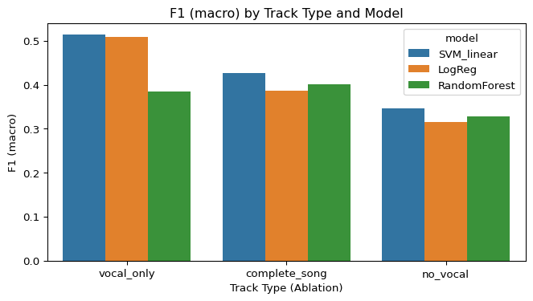

### Q2

How can we leverage audio features to construct a machine learning model capable of genre recognition?

## Results & Conclusion

### Yashi

**The project goal was to investigate how audio feature engineering can support language classification in music. Our analysis demonstrated that vocal-only features drive most of the predictive signal, confirming that separated vocals provide the strongest basis for language recognition. These results demonstrate the potential of classical machine learning for this task, but also highlight its limits，larger datasets and deep learning methods will be needed for stronger multilingual classification in the future.**

## sources

[1] https://link.springer.com/chapter/10.1007/978-981-97-4533-3_6

[2] https://arxiv.org/html/2411.14474v1